# HousingProject_team12

```python
import os
os.environ['JAVA_HOME'] = '/usr/lib/jvm/java-8-openjdk-amd64'
```

```python
import pyspark
import os.path

from pyspark import SparkContext
from pyspark.sql import SQLContext
from pyspark.sql import SparkSession
import pyspark.sql.functions as f

from pyspark.ml.linalg import Vectors
from pyspark.ml.stat import Correlation

from pyspark.sql import types
from pyspark.sql.types import StringType
from pyspark.sql.functions import desc
```

```python
conf = pyspark.SparkConf().setAll([('spark.app.name', 'Spark Data Exploration'),
                                  ('spark.driver.memory','10g')])
spark = SparkSession.builder.config(conf=conf).getOrCreate()

print (spark.version)
print (pyspark.version)

conf.getAll()
```

```
2.3.2
<module 'pyspark.version' from '/usr/local/lib/python3.6/dist-packages/pyspark/version.py'>
```

```
dict_items([('spark.app.name', 'Spark Data Exploration'), ('spark.driver.memory', '10g')])
```

```python
fpathA = 'property_features_2016.csv'
# fpathB = 'property_features_2017.csv'
#ddict_fpath = '../data_dict.pickle'

house2016 = spark.read.csv(fpathA, header=True, inferSchema=True).cache()
# house2017 = spark.read.csv(fpathB, header=True, inferSchema=True).cache()
```

#### Count rows in the original dataset

```python
print("The number of rows in house2016:  ", house2016.count())
```

```
The number of rows in house2016:   2985217
```

#### Next, we want to know how many rows remains if we drop Nulls for each of the variable

```python
Count_row = {}
for col in house2016.columns:
    Count_row[col] = house2016.select(col).dropna(how='any').count()
```

```python
#### Plot the number of not Null values in each variable
```

```python
import matplotlib.pyplot as plt
plt.figure(figsize=(10, 12))
plt.barh(*zip(*sorted(Count_row.items(), key=lambda x: x[1])), color = 'lightblue', align='center')

# plt.bar(range(len(Count_row)), Count_row.values(), align='center')
#plt.xticks(range(len(Count_row)), list(Count_row.keys()))
plt.title('Number of Valid Values')
plt.show()
```

[output not shown]

```python
#### Let's create a list of all the 'id' type variable list
```

```python
type_col =[ft for ft in house2016.columns if 'id' in ft]
type_col
```

```
['parcelid',
 'airconditioningtypeid',
 'architecturalstyletypeid',
 'buildingclasstypeid',
 'buildingqualitytypeid',
 'decktypeid',
 'heatingorsystemtypeid',
 'pooltypeid10',
 'pooltypeid2',
 'pooltypeid7',
 'propertylandusetypeid',
 'regionidcity',
 'regionidcounty',
 'regionidneighborhood',
 'regionidzip',
 'storytypeid',
 'typeconstructiontypeid']
```

```python
from pyspark.sql.types import StringType
```

#### Then change the id data type to string so that we can properky explore the dataset

```python
# Change id type to string

House2016 = house2016.withColumn("airconditioningtypeid", house2016["airconditioningtypeid"].cast(StringType()))
House2016 = House2016.withColumn("buildingqualitytypeid", House2016["buildingqualitytypeid"].cast(StringType()))
House2016 = House2016.withColumn("heatingorsystemtypeid", House2016["heatingorsystemtypeid"].cast(StringType()))
House2016 = House2016.withColumn("propertylandusetypeid", House2016["propertylandusetypeid"].cast(StringType()))
House2016 = House2016.withColumn("regionidcity", House2016["regionidcity"].cast(StringType()))
House2016 = House2016.withColumn("regionidcounty", House2016["regionidcounty"].cast(StringType()))
House2016 = House2016.withColumn("regionidneighborhood", House2016["regionidneighborhood"].cast(StringType()))
House2016 = House2016.withColumn("regionidzip", House2016["regionidzip"].cast(StringType()))
House2016 = House2016.withColumn("parcelid", house2016["parcelid"].cast(StringType()))
House2016 = House2016.withColumn("architecturalstyletypeid", House2016["architecturalstyletypeid"].cast(StringType()))
House2016 = House2016.withColumn("buildingclasstypeid", House2016["buildingclasstypeid"].cast(StringType()))
House2016 = House2016.withColumn("decktypeid", House2016["decktypeid"].cast(StringType()))
House2016 = House2016.withColumn("pooltypeid10", House2016["pooltypeid10"].cast(StringType()))
House2016 = House2016.withColumn("pooltypeid2", House2016["pooltypeid2"].cast(StringType()))
House2016 = House2016.withColumn("pooltypeid7", House2016["pooltypeid7"].cast(StringType()))
House2016 = House2016.withColumn("typeconstructiontypeid", house2016["typeconstructiontypeid"].cast(StringType()))
House2016 = House2016.withColumn("storytypeid", House2016["storytypeid"].cast(StringType()))
```

```python
House2016.printSchema()
```

```
root
 |-- parcelid: string (nullable = true)
 |-- airconditioningtypeid: string (nullable = true)
 |-- architecturalstyletypeid: string (nullable = true)
 |-- basementsqft: integer (nullable = true)
 |-- bathroomcnt: double (nullable = true)
 |-- bedroomcnt: double (nullable = true)
 |-- buildingclasstypeid: string (nullable = true)
 |-- buildingqualitytypeid: string (nullable = true)
 |-- calculatedbathnbr: double (nullable = true)
 |-- decktypeid: string (nullable = true)
 |-- finishedfloor1squarefeet: integer (nullable = true)
 |-- calculatedfinishedsquarefeet: double (nullable = true)
 |-- finishedsquarefeet12: integer (nullable = true)
 |-- finishedsquarefeet13: integer (nullable = true)
 |-- finishedsquarefeet15: integer (nullable = true)
 |-- finishedsquarefeet50: integer (nullable = true)
 |-- finishedsquarefeet6: integer (nullable = true)
 |-- fips: integer (nullable = true)
 |-- fireplacecnt: integer (nullable = true)
 |-- fullbathcnt: integer (nullable = true)
 |-- garagecarcnt: integer (nullable = true)
 |-- garagetotalsqft: integer (nullable = true)
 |-- hashottuborspa: boolean (nullable = true)
 |-- heatingorsystemtypeid: string (nullable = true)
 |-- latitude: integer (nullable = true)
 |-- longitude: integer (nullable = true)
 |-- lotsizesquarefeet: double (nullable = true)
 |-- poolcnt: integer (nullable = true)
 |-- poolsizesum: integer (nullable = true)
 |-- pooltypeid10: string (nullable = true)
 |-- pooltypeid2: string (nullable = true)
 |-- pooltypeid7: string (nullable = true)
 |-- propertycountylandusecode: string (nullable = true)
 |-- propertylandusetypeid: string (nullable = true)
 |-- propertyzoningdesc: string (nullable = true)
 |-- rawcensustractandblock: double (nullable = true)
 |-- regionidcity: string (nullable = true)
 |-- regionidcounty: string (nullable = true)
 |-- regionidneighborhood: string (nullable = true)
 |-- regionidzip: string (nullable = true)
 |-- roomcnt: double (nullable = true)
 |-- storytypeid: string (nullable = true)
 |-- threequarterbathnbr: integer (nullable = true)
 |-- typeconstructiontypeid: string (nullable = true)
 |-- unitcnt: integer (nullable = true)
 |-- yardbuildingsqft17: integer (nullable = true)
 |-- yardbuildingsqft26: integer (nullable = true)
 |-- yearbuilt: double (nullable = true)
 |-- numberofstories: integer (nullable = true)
 |-- fireplaceflag: boolean (nullable = true)
 |-- structuretaxvaluedollarcnt: double (nullable = true)
 |-- taxvaluedollarcnt: double (nullable = true)
 |-- assessmentyear: integer (nullable = true)
 |-- landtaxvaluedollarcnt: double (nullable = true)
 |-- taxamount: double (nullable = true)
 |-- taxdelinquencyflag: string (nullable = true)
 |-- taxdelinquencyyear: integer (nullable = true)
 |-- censustractandblock: long (nullable = true)
```

#### Filter out all the null in zip codes

```python
from pyspark.sql.functions import col, avg
# House2016.filter((f.col('taxvaluedollarcnt') < mean_txprice + 5*std_txprice) & (f.col('taxvaluedollarcnt') > 0))
House2016 = house2016.where(col("regionidzip").isNotNull())

House2016.count()
```

```
2971237
```

#### Filter out all the null in County codes

```python
House2016 = House2016.where(col("regionidcounty").isNotNull())

House2016.count()
```

```
2971237
```

#### Based on our backdround research and null value plot, we will first drop the following 'id' variables

```python
drop = ["regionidcity", "regionidneighborhood", "parcelid", "pooltypeid10", "pooltypeid2", "pooltypeid7"]
```

```python
type_colDr = [c for c in type_col if c not in drop]
```

#### updated 'id' variables

```python
type_colDr
```

```
['airconditioningtypeid',
 'architecturalstyletypeid',
 'buildingclasstypeid',
 'buildingqualitytypeid',
 'decktypeid',
 'heatingorsystemtypeid',
 'propertylandusetypeid',
 'regionidcounty',
 'regionidzip',
 'storytypeid',
 'typeconstructiontypeid']
```

### Imputaion for 'id' type variables: we'll use the most common (mode) category of each variable to fill na.

```python
from pyspark.sql.functions import desc

type_dict={}
for i in type_colDr:
    type_dict[i] = House2016.groupBy(i).count().sort(desc("count")).collect()[1][0]
    # House2016.groupBy(i).count().sort(desc("count")).show(2)
```

```python
type_dict
```

```
{'airconditioningtypeid': 1,
 'architecturalstyletypeid': 7,
 'buildingclasstypeid': 4,
 'buildingqualitytypeid': None,
 'decktypeid': 66,
 'heatingorsystemtypeid': 2,
 'propertylandusetypeid': 266,
 'regionidcounty': 1286,
 'regionidzip': 96193,
 'storytypeid': 7,
 'typeconstructiontypeid': 6}
```

#### We then realized many 'id' variables have 'null' as the most frequent 'category', so we decided to use the 2nd most frequent to fill NA.

```python
from pyspark.sql.functions import desc

for i in type_colDr:
    House2016.groupBy(i).count().sort(desc("count")).show(3)
    # House2016.groupBy(i).count().sort(desc("count")).show(2)
```

```
+---------------------+-------+
|airconditioningtypeid|  count|
+---------------------+-------+
|                 null|2159981|
|                    1| 742110|
|                   13|  58448|
+---------------------+-------+
only showing top 3 rows

+------------------------+-------+
|architecturalstyletypeid|  count|
+------------------------+-------+
|                    null|2965176|
|                       7|   5251|
|                       8|    380|
+------------------------+-------+
only showing top 3 rows

+-------------------+-------+
|buildingclasstypeid|  count|
+-------------------+-------+
|               null|2958610|
|                  4|   9263|
|                  3|   3161|
+-------------------+-------+
only showing top 3 rows

+---------------------+-------+
|buildingqualitytypeid|  count|
+---------------------+-------+
|                    7|1133234|
|                 null|1032754|
|                    4| 692159|
+---------------------+-------+
only showing top 3 rows

+----------+-------+
|decktypeid|  count|
+----------+-------+
|      null|2954180|
```

[output cut: 38 more lines]

```
+-----------+-------+
|storytypeid|  count|
+-----------+-------+
|       null|2969619|
|          7|   1618|
+-----------+-------+

+----------------------+-------+
|typeconstructiontypeid|  count|
+----------------------+-------+
|                  null|2964490|
|                     6|   6670|
|                     4|     59|
+----------------------+-------+
only showing top 3 rows
```

#### Update the 2nd most count for some variables

```python
type_dict.update({'regionidzip': '96987',
                 'regionidcounty': '3101',
                 'buildingqualitytypeid': '7',
                 'propertylandusetypeid': '261',
                 })
```

#### Impute

```python
House2016 = House2016.na.fill(type_dict)
```

> As we learned from our research that zip code could potentially influnce the tax assessment, and there could be many many zip codes.  
> Therefore, we will explore the zip code a bit at this point.

#### First, let's see how many distinct zip codes: 405

```python
from pyspark.sql.functions import  mean , stddev, col

House2016.select('regionidzip').agg(f.countDistinct('regionidzip')).show()
```

```
+---------------------------+
|count(DISTINCT regionidzip)|
+---------------------------+
|                        405|
+---------------------------+
```

#### Then, we wondered what's the average number of houses included in each zip code, as well as the standard deveiation across the counts.

```python
House2016.groupBy("regionidzip").count().sort('count').select(mean('count'),stddev('count')).show()
```

```
+-----------------+------------------+
|       avg(count)|stddev_samp(count)|
+-----------------+------------------+
|7336.387654320988| 4511.408729334391|
+-----------------+------------------+
```

#### The std.dev is quite large, we should remove some outlier zips.

```python
zip_count = House2016.groupBy("regionidzip").count().sort('count').select("regionidzip",'count')
```

```python
# Filter counted zip greater than mean-std and mean
zip0 = zip_count.filter(col('count') > 5000).select('regionidzip', 'count').collect()
```

```python
# zip and zip count for counted zip greater than mean-std
zipv = [row[1] for row in zip0]
zipz = [row[0] for row in zip0]
```

```python
print("There're",  len(zipz), "unique zip codes left after the filteration.")
```

```
There're 281 unique zip codes left after the filteration.
```

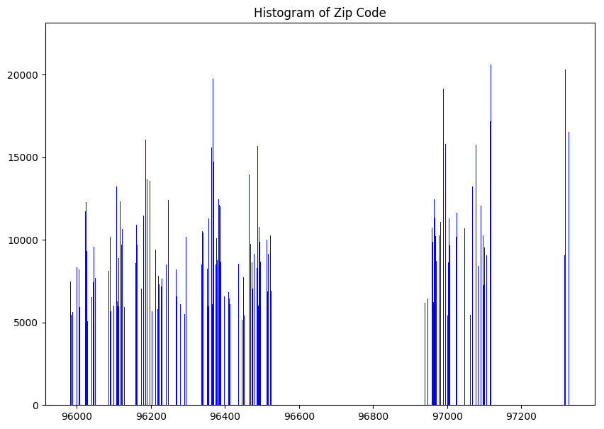

```python
# Plot how strong a variable is correlated with response variable
import matplotlib.pyplot as plt
plt.rcdefaults()
#fig, ax = plt.subplots()
plt.figure(figsize=(10, 7))

#corr_df = pd.DataFrame(data = cor_value)
#plt.plot(cor_names, cor_value, label = cor_names)
plt.bar(zipz, zipv, align='center',
        color='blue', ecolor='black')
plt.title('Histogram of Zip Code')
plt.savefig('zip_plot.png')
plt.show()
```

#### Filter the data with zip code condition

```python
zip_House = House2016.where(House2016.regionidzip.isin(zipz))
```

### Now, get the numeric variables

```python
# Get all numeric type VAR
numeric_features16 = [t[0] for t in zip_House.dtypes if t[1] != "boolean" and t[1] != "string" and t[0] not in type_col]
numeric_features16 = [ft for ft in numeric_features16 if ft not in type_col and ft not in drop]
numeric_features16
```

```
['basementsqft',
 'bathroomcnt',
 'bedroomcnt',
 'calculatedbathnbr',
 'finishedfloor1squarefeet',
 'calculatedfinishedsquarefeet',
 'finishedsquarefeet12',
 'finishedsquarefeet13',
 'finishedsquarefeet15',
 'finishedsquarefeet50',
 'finishedsquarefeet6',
 'fips',
 'fireplacecnt',
 'fullbathcnt',
 'garagecarcnt',
 'garagetotalsqft',
 'latitude',
 'longitude',
 'lotsizesquarefeet',
 'poolcnt',
 'poolsizesum',
 'rawcensustractandblock',
 'roomcnt',
 'threequarterbathnbr',
 'unitcnt',
 'yardbuildingsqft17',
 'yardbuildingsqft26',
 'yearbuilt',
 'numberofstories',
 'structuretaxvaluedollarcnt',
 'taxvaluedollarcnt',
 'assessmentyear',
 'landtaxvaluedollarcnt',
 'taxamount',
 'taxdelinquencyyear',
 'censustractandblock']
```

# Impute Numeric None values by mean

```python
# Impute Numeric None values
meam_dict={}
for c in numeric_features16:
    m = zip_House.select(avg(zip_House[c])).collect()[0][0]
    #print(m)
    # meam_list.append(m)
    meam_dict[c] = m
    #House2016.select(numeric_features16[i]).na.fill(m).show(3)
```

```python
meam_dict
```

```
{'basementsqft': 647.895652173913,
 'bathroomcnt': 2.2074849468295192,
 'bedroomcnt': 3.1033735496419284,
 'calculatedbathnbr': 2.295578341765764,
 'finishedfloor1squarefeet': 1382.6442713455403,
 'calculatedfinishedsquarefeet': 1813.5716483779934,
 'finishedsquarefeet12': 1759.8635967383584,
 'finishedsquarefeet13': 1180.6752493933675,
 'finishedsquarefeet15': 2627.1679553990307,
 'finishedsquarefeet50': 1390.8713882081142,
 'finishedsquarefeet6': 2471.0858960176993,
 'fips': 6048.45293723126,
 'fireplacecnt': 1.1669700760387958,
 'fullbathcnt': 2.2396122968019294,
 'garagecarcnt': 1.8232444522069882,
 'garagetotalsqft': 383.15738678815046,
 'latitude': 34001813.918839194,
 'longitude': -118200430.76303254,
 'lotsizesquarefeet': 21964.877961956732,
 'poolcnt': 1.0,
 'poolsizesum': 521.1461153846154,
 'rawcensustractandblock': 60487614.93282979,
 'roomcnt': 1.5416538894761531,
 'threequarterbathnbr': 1.0088096801687882,
 'unitcnt': 1.1631564459640993,
 'yardbuildingsqft17': 320.6232412373297,
 'yardbuildingsqft26': 267.9068010075567,
 'yearbuilt': 1964.7416974365324,
 'numberofstories': 1.3981586213909682,
 'structuretaxvaluedollarcnt': 167257.9619801787,
 'taxvaluedollarcnt': 408774.5643702705,
 'assessmentyear': 2015.0000003726032,
 'landtaxvaluedollarcnt': 244391.25487808912,
 'taxamount': 5226.537456272089,
 'taxdelinquencyyear': 13.884521180485846,
 'censustractandblock': 60488476107277.54}
```

```python
meam_dict.update({'yearbuilt':1965})
```

```python
meam_dict
```

```
{'basementsqft': 647.895652173913,
 'bathroomcnt': 2.2074849468295192,
 'bedroomcnt': 3.1033735496419284,
 'calculatedbathnbr': 2.295578341765764,
 'finishedfloor1squarefeet': 1382.6442713455403,
 'calculatedfinishedsquarefeet': 1813.5716483779934,
 'finishedsquarefeet12': 1759.8635967383584,
 'finishedsquarefeet13': 1180.6752493933675,
 'finishedsquarefeet15': 2627.1679553990307,
 'finishedsquarefeet50': 1390.8713882081142,
 'finishedsquarefeet6': 2471.0858960176993,
 'fips': 6048.45293723126,
 'fireplacecnt': 1.1669700760387958,
 'fullbathcnt': 2.2396122968019294,
 'garagecarcnt': 1.8232444522069882,
 'garagetotalsqft': 383.15738678815046,
 'latitude': 34001813.918839194,
 'longitude': -118200430.76303254,
 'lotsizesquarefeet': 21964.877961956732,
 'poolcnt': 1.0,
 'poolsizesum': 521.1461153846154,
 'rawcensustractandblock': 60487614.93282979,
 'roomcnt': 1.5416538894761531,
 'threequarterbathnbr': 1.0088096801687882,
 'unitcnt': 1.1631564459640993,
 'yardbuildingsqft17': 320.6232412373297,
 'yardbuildingsqft26': 267.9068010075567,
 'yearbuilt': 1965,
 'numberofstories': 1.3981586213909682,
 'structuretaxvaluedollarcnt': 167257.9619801787,
 'taxvaluedollarcnt': 408774.5643702705,
 'assessmentyear': 2015.0000003726032,
 'landtaxvaluedollarcnt': 244391.25487808912,
 'taxamount': 5226.537456272089,
 'taxdelinquencyyear': 13.884521180485846,
 'censustractandblock': 60488476107277.54}
```

```python
House2016 = zip_House.na.fill(meam_dict)
```

```python
drop_col = []
for col in house2016.columns:
    if col not in type_colDr and col not in numeric_features16:
        print(col)
        drop_col.append(col)
drop_col
```

```
parcelid
hashottuborspa
pooltypeid10
pooltypeid2
pooltypeid7
propertycountylandusecode
propertyzoningdesc
regionidcity
regionidneighborhood
fireplaceflag
taxdelinquencyflag
```

```
['parcelid',
 'hashottuborspa',
 'pooltypeid10',
 'pooltypeid2',
 'pooltypeid7',
 'propertycountylandusecode',
 'propertyzoningdesc',
 'regionidcity',
 'regionidneighborhood',
 'fireplaceflag',
 'taxdelinquencyflag']
```

```python
sel = type_colDr+numeric_features16
```

```python
HouseDf = House2016.select(sel)
```

```python
HouseDf.printSchema()
```

```
root
 |-- airconditioningtypeid: integer (nullable = false)
 |-- architecturalstyletypeid: integer (nullable = false)
 |-- buildingclasstypeid: integer (nullable = false)
 |-- buildingqualitytypeid: integer (nullable = true)
 |-- decktypeid: integer (nullable = false)
 |-- heatingorsystemtypeid: integer (nullable = false)
 |-- propertylandusetypeid: integer (nullable = true)
 |-- regionidcounty: integer (nullable = true)
 |-- regionidzip: integer (nullable = true)
 |-- storytypeid: integer (nullable = false)
 |-- typeconstructiontypeid: integer (nullable = false)
 |-- basementsqft: integer (nullable = true)
 |-- bathroomcnt: double (nullable = false)
 |-- bedroomcnt: double (nullable = false)
 |-- calculatedbathnbr: double (nullable = false)
 |-- finishedfloor1squarefeet: integer (nullable = true)
 |-- calculatedfinishedsquarefeet: double (nullable = false)
 |-- finishedsquarefeet12: integer (nullable = true)
 |-- finishedsquarefeet13: integer (nullable = true)
 |-- finishedsquarefeet15: integer (nullable = true)
 |-- finishedsquarefeet50: integer (nullable = true)
 |-- finishedsquarefeet6: integer (nullable = true)
 |-- fips: integer (nullable = true)
 |-- fireplacecnt: integer (nullable = true)
 |-- fullbathcnt: integer (nullable = true)
 |-- garagecarcnt: integer (nullable = true)
 |-- garagetotalsqft: integer (nullable = true)
 |-- latitude: integer (nullable = true)
 |-- longitude: integer (nullable = true)
 |-- lotsizesquarefeet: double (nullable = false)
 |-- poolcnt: integer (nullable = true)
 |-- poolsizesum: integer (nullable = true)
 |-- rawcensustractandblock: double (nullable = false)
 |-- roomcnt: double (nullable = false)
 |-- threequarterbathnbr: integer (nullable = true)
 |-- unitcnt: integer (nullable = true)
 |-- yardbuildingsqft17: integer (nullable = true)
 |-- yardbuildingsqft26: integer (nullable = true)
 |-- yearbuilt: double (nullable = false)
 |-- numberofstories: integer (nullable = true)
 |-- structuretaxvaluedollarcnt: double (nullable = false)
 |-- taxvaluedollarcnt: double (nullable = false)
 |-- assessmentyear: integer (nullable = true)
 |-- landtaxvaluedollarcnt: double (nullable = false)
 |-- taxamount: double (nullable = false)
 |-- taxdelinquencyyear: integer (nullable = true)
 |-- censustractandblock: long (nullable = true)
```

```python
Count_row11 = {}
for col in HouseDf.columns:
    Count_row11[col] = HouseDf.select(col).dropna(how='any').count()
Count_row11
```

```
{'airconditioningtypeid': 2683820,
 'architecturalstyletypeid': 2683820,
 'buildingclasstypeid': 2683820,
 'buildingqualitytypeid': 2683820,
 'decktypeid': 2683820,
 'heatingorsystemtypeid': 2683820,
 'propertylandusetypeid': 2683820,
 'regionidcounty': 2683820,
 'regionidzip': 2683820,
 'storytypeid': 2683820,
 'typeconstructiontypeid': 2683820,
 'basementsqft': 2683820,
 'bathroomcnt': 2683820,
 'bedroomcnt': 2683820,
 'calculatedbathnbr': 2683820,
 'finishedfloor1squarefeet': 2683820,
 'calculatedfinishedsquarefeet': 2683820,
 'finishedsquarefeet12': 2683820,
 'finishedsquarefeet13': 2683820,
 'finishedsquarefeet15': 2683820,
 'finishedsquarefeet50': 2683820,
 'finishedsquarefeet6': 2683820,
 'fips': 2683820,
 'fireplacecnt': 2683820,
 'fullbathcnt': 2683820,
 'garagecarcnt': 2683820,
 'garagetotalsqft': 2683820,
 'latitude': 2683820,
 'longitude': 2683820,
 'lotsizesquarefeet': 2683820,
 'poolcnt': 2683820,
 'poolsizesum': 2683820,
 'rawcensustractandblock': 2683820,
 'roomcnt': 2683820,
 'threequarterbathnbr': 2683820,
 'unitcnt': 2683820,
 'yardbuildingsqft17': 2683820,
 'yardbuildingsqft26': 2683820,
 'yearbuilt': 2683820,
 'numberofstories': 2683820,
 'structuretaxvaluedollarcnt': 2683820,
 'taxvaluedollarcnt': 2683820,
 'assessmentyear': 2683820,
 'landtaxvaluedollarcnt': 2683820,
 'taxamount': 2683820,
 'taxdelinquencyyear': 2683820,
 'censustractandblock': 2683820}
```

### None values cleaned!!

```python
HouseDf.na.drop().count() - HouseDf.count()
```

```
0
```

#### Stats about all the numeric features

```python
HouseDf.select(numeric_features16).describe().toPandas().transpose()
```

|  | 0 | 1 | 2 | 3 | 4 |
| --- | --- | --- | --- | --- | --- |
| summary | count | mean | stddev | min | max |
| basementsqft | 2683820 | 647.0004989157246 | 12.814841232135716 | 20 | 8516 |
| bathroomcnt | 2683820 | 2.2074849468295192 | 1.0595820701077143 | 0.0 | 20.0 |
| bedroomcnt | 2683820 | 3.1033735496419284 | 1.2495052738662766 | 0.0 | 20.0 |
| calculatedbathnbr | 2683820 | 2.2955783417660793 | 0.9631771799612371 | 1.0 | 20.0 |
| finishedfloor1squarefeet | 2683820 | 1382.046134986698 | 168.0779321433231 | 3 | 17748 |
| calculatedfinishedsquarefeet | 2683820 | 1813.5716483778153 | 1453.3875858507695 | 1.0 | 617114.0 |
| finishedsquarefeet12 | 2683820 | 1759.793229799316 | 904.985943029636 | 1 | 290345 |
| finishedsquarefeet13 | 2683820 | 1180.0018663695778 | 18.635741856787227 | 120 | 2688 |
| finishedsquarefeet15 | 2683820 | 2627.009631048282 | 1051.6662430264553 | 112 | 617114 |
| finishedsquarefeet50 | 2683820 | 1390.062398372469 | 176.6699175082953 | 3 | 25686 |
| finishedsquarefeet6 | 2683820 | 2471.000578652816 | 377.36319255476764 | 117 | 531118 |
| fips | 2683820 | 6048.45293723126 | 20.572908805040445 | 6037 | 6111 |
| fireplacecnt | 2683820 | 1.0183518268736353 | 0.1609975065143112 | 1 | 9 |
| fullbathcnt | 2683820 | 2.2303537495063006 | 0.9554811104360273 | 1 | 20 |
| garagecarcnt | 2683820 | 1.252901461349867 | 0.5011858594659288 | 0 | 25 |
| garagetotalsqft | 2683820 | 383.0483493676923 | 133.78019423731303 | 0 | 7749 |
| latitude | 2683820 | 3.4001813918839194E7 | 246535.7467099545 | 33389318 | 34819650 |
| longitude | 2683820 | -1.1820043076303254E8 | 352885.2802397478 | -119450824 | -117554316 |
| lotsizesquarefeet | 2683820 | 21964.877961967515 | 332408.6810954567 | 100.0 | 3.28263808E8 |
| poolcnt | 2683820 | 1.0 | 0.0 | 1 | 1 |
| poolsizesum | 2683820 | 521.0014155196698 | 16.153362429922844 | 19 | 6000 |
| rawcensustractandblock | 2683820 | 6.048761493282979E7 | 204205.7047654755 | 6.0371011101E7 | 6.1110091003011E7 |
| roomcnt | 2683820 | 1.5416538894761531 | 2.88692235473817 | 0.0 | 96.0 |
| threequarterbathnbr | 2683820 | 1.000939705345366 | 0.035758032959925 | 1 | 7 |
| unitcnt | 2683820 | 1.10689129673376 | 1.9007289621444663 | 1 | 997 |
| yardbuildingsqft17 | 2683820 | 320.0177094589056 | 39.18890196385694 | 10 | 7983 |
| yardbuildingsqft26 | 2683820 | 267.0008048229762 | 10.450573435364143 | 10 | 6141 |
| yearbuilt | 2683820 | 1964.7457817588363 | 22.625587937407406 | 1801.0 | 2015.0 |
| numberofstories | 2683820 | 1.0948278945681902 | 0.3118659350575201 | 1 | 41 |
| structuretaxvaluedollarcnt | 2683820 | 167257.9619801727 | 297284.8064783915 | 1.0 | 1.39293248E8 |
| taxvaluedollarcnt | 2683820 | 408774.56437025446 | 597044.5781729617 | 1.0 | 1.49613482E8 |
| assessmentyear | 2683820 | 2015.0000003726032 | 6.104123441142048E-4 | 2015 | 2016 |
| landtaxvaluedollarcnt | 2683820 | 244391.25487812248 | 390112.17994326307 | 1.0 | 4.8986706E7 |
| taxamount | 2683820 | 5226.537456271727 | 7493.774134178293 | 1.34 | 1840935.06 |
| taxdelinquencyyear | 2683820 | 13.016416153095214 | 0.3583754034029674 | 0 | 99 |
| censustractandblock | 2683820 | 6.048847610727156E13 | 3.340054228995646E11 | -1 | 483030105084015 |

### Now we want to see how our features are correlated with each other

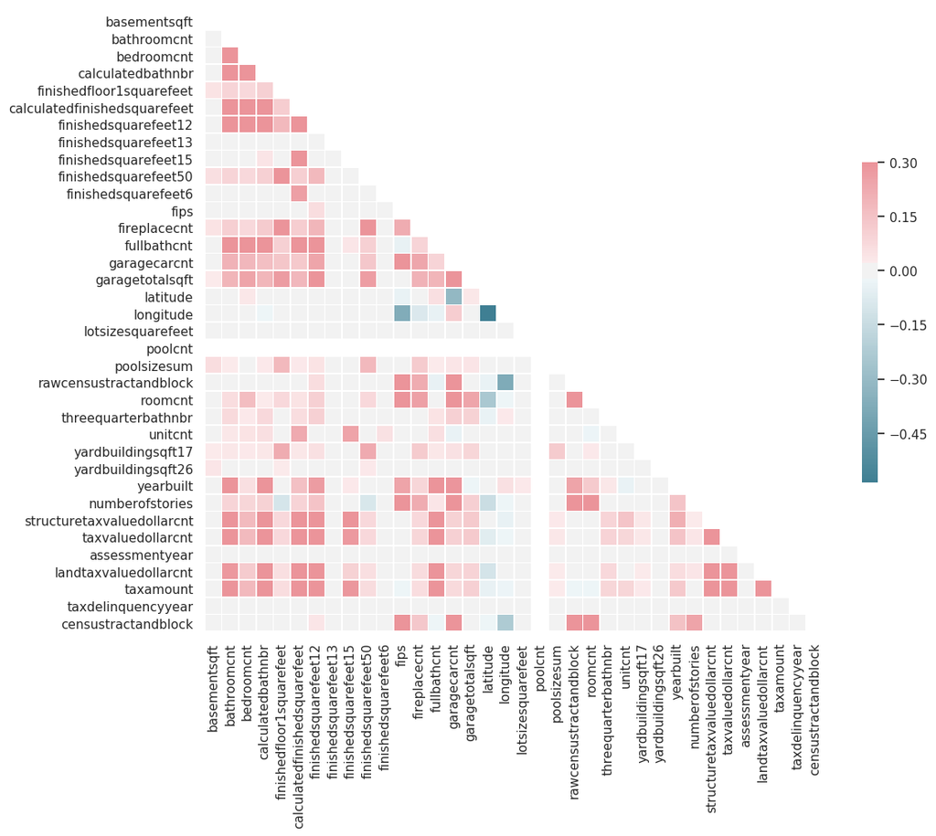

```python
# Plot correlation among variables(numerical only)
from string import ascii_letters
import seaborn as sns
import numpy as np

sns.set(style="white")

# Compute the correlation matrix
corr = HouseDf[numeric_features16].toPandas().corr()

# Generate a mask for the upper triangle
mask = np.zeros_like(corr, dtype=np.bool)
mask[np.triu_indices_from(mask)] = True

# Set up the matplotlib figure
f, ax = plt.subplots(figsize=(12, 10))

# Generate a custom diverging colormap
cmap = sns.diverging_palette(220, 10, as_cmap=True)

# Draw the heatmap with the mask and correct aspect ratio
sns.heatmap(corr, mask=mask, cmap=cmap, vmax=.3, center=0,
            square=True, linewidths=.5, cbar_kws={"shrink": .5})
plt.savefig('num_corPlot.png')
```

### Also how features are correc\lated to our response variable - 'taxvaluedollarcnt'

```python
pyspark.sql.DataFrame.dtypes
cor_value = []
cor_names = []
for col in numeric_features16:
    #if t != "boolean" and t != "string":
    print(col, '\t\t', HouseDf.stat.corr('taxvaluedollarcnt', col))
    cor_value.append(HouseDf.stat.corr('taxvaluedollarcnt', col))
    cor_names.append(col)
```

```
basementsqft 		 0.01805149766127698
bathroomcnt 		 0.3696070890490015
bedroomcnt 		 0.17415985844146975
calculatedbathnbr 		 0.405234089078775
finishedfloor1squarefeet 		 0.08081790858614783
calculatedfinishedsquarefeet 		 0.5237088708266852
finishedsquarefeet12 		 0.5096490121483217
finishedsquarefeet13 		 -0.0034907294069062415
finishedsquarefeet15 		 0.2809832165418459
finishedsquarefeet50 		 0.08182874588248186
finishedsquarefeet6 		 0.009191999699263376
fips 		 0.00329417662033179
fireplacecnt 		 0.08680705608196936
fullbathcnt 		 0.39328731202124795
garagecarcnt 		 0.10831886409214551
garagetotalsqft 		 0.12569333699417828
latitude 		 -0.06582332567447154
longitude 		 -0.027962727707293168
lotsizesquarefeet 		 0.003137086423457311
poolcnt 		 nan
poolsizesum 		 0.030303740592498265
rawcensustractandblock 		 0.003020001319248574
roomcnt 		 0.007098337975657994
threequarterbathnbr 		 0.09774769309157294
unitcnt 		 0.08383112983743624
yardbuildingsqft17 		 0.03183789787427653
yardbuildingsqft26 		 0.004092497375239974
yearbuilt 		 0.14707704089710286
numberofstories 		 0.0402270684958037
structuretaxvaluedollarcnt 		 0.822481836723147
taxvaluedollarcnt 		 1.0
assessmentyear 		 -0.00020295638990651982
landtaxvaluedollarcnt 		 0.8994730732323326
taxamount 		 0.950184732139935
taxdelinquencyyear 		 0.001455630677540741
censustractandblock 		 0.00290032708035248
```

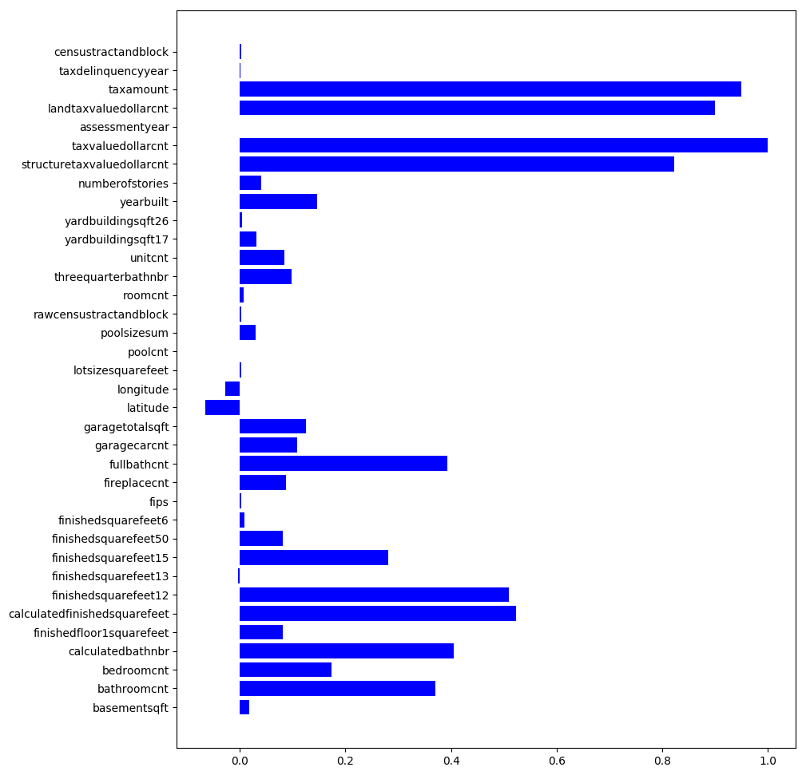

```python
# Plot how strong a variable is correlated with response variable
import matplotlib.pyplot as plt
plt.rcdefaults()
#fig, ax = plt.subplots()
plt.figure(figsize=(10, 12))

#corr_df = pd.DataFrame(data = cor_value)
#plt.plot(cor_names, cor_value, label = cor_names)
plt.barh(cor_names, cor_value, align='center',
        color='blue', ecolor='black')
plt.savefig('cor_plot.png')
plt.show()
```

```python
from pyspark.sql.functions import udf, col, avg, mean, stddev

mean_txprice = HouseDf.select(avg(HouseDf["taxvaluedollarcnt"])).collect()[0][0]
std_txprice = HouseDf.select(stddev(HouseDf["taxvaluedollarcnt"])).collect()[0][0]
```

```python
print("Average price is: ", mean_txprice, "\nStandard deviation of house price is: ", std_txprice)
```

```
Average price is:  408774.56437025446
Standard deviation of house price is:  597044.5781729617
```

#### The 10 lowest Average tax value by zip code

```python
# the smallest 10 Average tax value by zip code
HouseDf.groupBy("regionidzip").avg('taxvaluedollarcnt').sort('avg(taxvaluedollarcnt)').show(10)
```

```
+-----------+----------------------+
|regionidzip|avg(taxvaluedollarcnt)|
+-----------+----------------------+
|      97317|    133727.67283447614|
|      97328|    155953.39036243845|
|      96092|     162091.6904351132|
|      97318|    164811.92801706746|
|      96040|    173596.52163879096|
|      95983|     176777.4602219548|
|      97330|    182748.52527355772|
|      96091|    183221.73507672932|
|      95982|    188252.89804527425|
|      96090|    191119.61836800148|
+-----------+----------------------+
only showing top 10 rows
```

#### The 10 greatest Average tax value by zip code

```python
# the greatest 10 Average tax value by zip code
HouseDf.groupBy("regionidzip").avg('taxvaluedollarcnt').sort(desc('avg(taxvaluedollarcnt)')).show(10)
```

```
+-----------+----------------------+
|regionidzip|avg(taxvaluedollarcnt)|
+-----------+----------------------+
|      96086|    2708310.6582512315|
|      96116|    1840618.1586578002|
|      96120|    1488259.6317921209|
|      96030|    1449395.2823105108|
|      96969|    1213910.9391872424|
|      96121|    1104897.6433541386|
|      96117|    1102726.3427223242|
|      96940|    1091469.0793292485|
|      96978|     1053121.466249877|
|      96337|     993334.3118358863|
+-----------+----------------------+
only showing top 10 rows
```

#### the top ten years-built in which most houses were built

```python
# the top 10 years in which most houses were built
HouseDf.groupBy("yearbuilt").count().sort(desc('count')).show(10)
```

```
+---------+-----+
|yearbuilt|count|
+---------+-----+
|   1965.0|88724|
|   1955.0|82824|
|   1950.0|70706|
|   1954.0|66885|
|   1953.0|61811|
|   1964.0|61519|
|   1956.0|61455|
|   1951.0|52207|
|   1963.0|51406|
|   1952.0|49697|
+---------+-----+
only showing top 10 rows
```

#### the top ten years-built in which least number of houses were built

```python
# the top 10 years in which least houses were built
HouseDf.groupBy("yearbuilt").count().sort('count').show(10)
```

```
+---------+-----+
|yearbuilt|count|
+---------+-----+
|   1828.0|    1|
|   1821.0|    1|
|   1853.0|    1|
|   1834.0|    1|
|   1833.0|    1|
|   1831.0|    1|
|   1810.0|    1|
|   1829.0|    1|
|   1878.0|    1|
|   1823.0|    1|
+---------+-----+
only showing top 10 rows
```

### Now let's see the tax assessments pattern varies among counties

```python
HouseDf = HouseDf.withColumn("regionidcounty", HouseDf["regionidcounty"].cast(StringType()))
mean_county = HouseDf.groupBy("regionidcounty").avg('taxvaluedollarcnt').toPandas().values
mean_by_county = [d[1] for d in mean_county]
```

```python
mean_zip = HouseDf.groupBy("regionidzip").avg('taxvaluedollarcnt').toPandas().values
mean_by_zip = [d[1] for d in mean_zip]
```

```python
countyid = [d[0] for d in mean_county]
zipid = [d[0] for d in mean_zip]
```

```python
countyid, mean_by_county
```

```
(['1286', '3101', '2061'],
 [441123.89198351523, 399196.99533251673, 384381.5477141324])
```

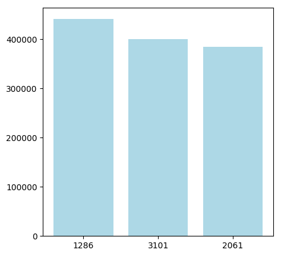

```python
import matplotlib.pyplot as plt
# plt.rcdefaults()
#fig, ax = plt.subplots()
plt.figure(figsize=(5, 5))

#corr_df = pd.DataFrame(data = cor_value)
#plt.plot(cor_names, cor_value, label = cor_names)
plt.bar(countyid, mean_by_county,
        color='lightblue')
#plt.savefig('m_byCounty_plot.png')
plt.show()
```

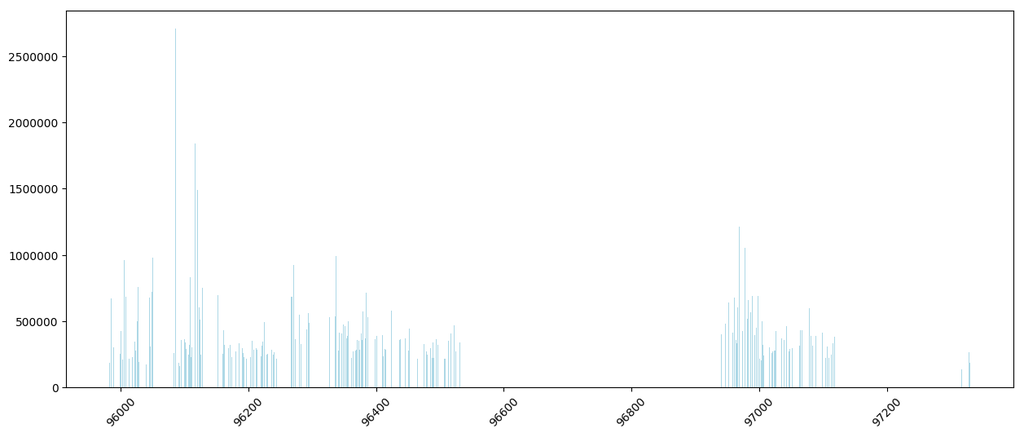

```python
# # Plot average price by Zipcode

import matplotlib.pyplot as plt
plt.rcdefaults()
#fig, ax = plt.subplots()
plt.figure(figsize=(15, 6))

#corr_df = pd.DataFrame(data = cor_value)
#plt.plot(cor_names, cor_value, label = cor_names)
plt.bar(zipid, mean_by_zip,align='center',
        color='lightblue', ecolor='grey')
#(zipid, mean_by_zip, align='center',color='grey', ecolor='black')
plt.xticks(rotation=45)
plt.savefig('meanZip_plot.png')
plt.show()
```

```python
corr_num={}
for i in range(len(cor_names)):
    corr_num[cor_names[i]] = cor_value[i]
corr_num
```

```
{'basementsqft': 0.018051497661276988,
 'bathroomcnt': 0.3696070890490015,
 'bedroomcnt': 0.17415985844146975,
 'calculatedbathnbr': 0.405234089078775,
 'finishedfloor1squarefeet': 0.08081790858614785,
 'calculatedfinishedsquarefeet': 0.5237088708266852,
 'finishedsquarefeet12': 0.5096490121483217,
 'finishedsquarefeet13': -0.003490729406906238,
 'finishedsquarefeet15': 0.2809832165418459,
 'finishedsquarefeet50': 0.08182874588248186,
 'finishedsquarefeet6': 0.009191999699263376,
 'fips': 0.003294176620331776,
 'fireplacecnt': 0.08680705608196934,
 'fullbathcnt': 0.39328731202124795,
 'garagecarcnt': 0.10831886409214547,
 'garagetotalsqft': 0.12569333699417828,
 'latitude': -0.06582332567447151,
 'longitude': -0.027962727707293158,
 'lotsizesquarefeet': 0.0031370864234573116,
 'poolcnt': nan,
 'poolsizesum': 0.030303740592498272,
 'rawcensustractandblock': 0.003020001319248574,
 'roomcnt': 0.007098337975657993,
 'threequarterbathnbr': 0.09774769309157294,
 'unitcnt': 0.08383112983743624,
 'yardbuildingsqft17': 0.03183789787427654,
 'yardbuildingsqft26': 0.004092497375239974,
 'yearbuilt': 0.14707704089710283,
 'numberofstories': 0.0402270684958037,
 'structuretaxvaluedollarcnt': 0.8224818367231469,
 'taxvaluedollarcnt': 1.0,
 'assessmentyear': -0.00020295638983164246,
 'landtaxvaluedollarcnt': 0.8994730732323326,
 'taxamount': 0.950184732139935,
 'taxdelinquencyyear': 0.0014556306775407406,
 'censustractandblock': 0.002900327080352474}
```

### Visualize the correlation by corr values

```python
sorted(corr_num.items(), key=lambda x: x[1])
```

```
[('latitude', -0.06582332567447151),
 ('longitude', -0.027962727707293158),
 ('finishedsquarefeet13', -0.003490729406906238),
 ('assessmentyear', -0.00020295638983164246),
 ('taxdelinquencyyear', 0.0014556306775407406),
 ('censustractandblock', 0.002900327080352474),
 ('rawcensustractandblock', 0.003020001319248574),
 ('lotsizesquarefeet', 0.0031370864234573116),
 ('fips', 0.003294176620331776),
 ('yardbuildingsqft26', 0.004092497375239974),
 ('roomcnt', 0.007098337975657993),
 ('finishedsquarefeet6', 0.009191999699263376),
 ('basementsqft', 0.018051497661276988),
 ('poolsizesum', 0.030303740592498272),
 ('yardbuildingsqft17', 0.03183789787427654),
 ('numberofstories', 0.0402270684958037),
 ('finishedfloor1squarefeet', 0.08081790858614785),
 ('finishedsquarefeet50', 0.08182874588248186),
 ('unitcnt', 0.08383112983743624),
 ('fireplacecnt', 0.08680705608196934),
 ('threequarterbathnbr', 0.09774769309157294),
 ('garagecarcnt', 0.10831886409214547),
 ('garagetotalsqft', 0.12569333699417828),
 ('yearbuilt', 0.14707704089710283),
 ('bedroomcnt', 0.17415985844146975),
 ('finishedsquarefeet15', 0.2809832165418459),
 ('bathroomcnt', 0.3696070890490015),
 ('fullbathcnt', 0.39328731202124795),
 ('calculatedbathnbr', 0.405234089078775),
 ('finishedsquarefeet12', 0.5096490121483217),
 ('calculatedfinishedsquarefeet', 0.5237088708266852),
 ('poolcnt', nan),
 ('structuretaxvaluedollarcnt', 0.8224818367231469),
 ('landtaxvaluedollarcnt', 0.8994730732323326),
 ('taxamount', 0.950184732139935),
 ('taxvaluedollarcnt', 1.0)]
```

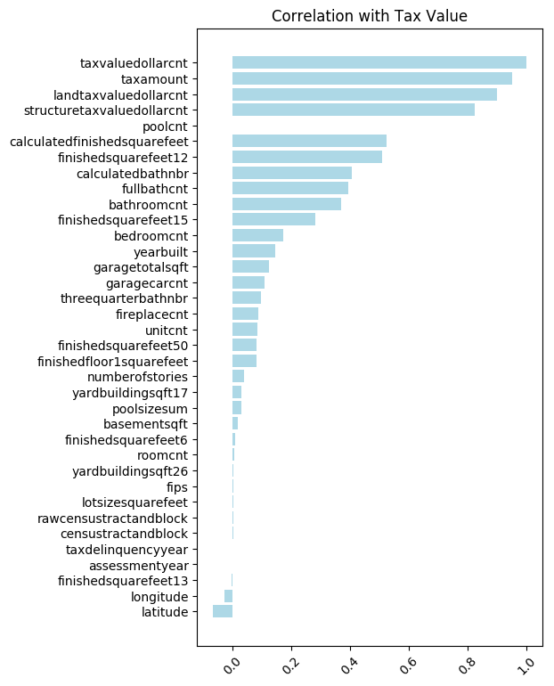

```python
# Plot the correlation by corr values

plt.rcdefaults()
#fig, ax = plt.subplots()
plt.figure(figsize=(5, 9))
x, y = zip(*sorted(corr_num.items(), key=lambda x: x[1])) # unpack a list of pairs into two tuples
plt.xticks(rotation=45)
plt.barh(x, y, align='center',
        color='lightblue', ecolor='grey')
plt.title('Correlation with Tax Value')
plt.savefig('correlation_num_plot.png')
plt.show()
```

#### get numeric features with highly correlated to response var

```python
# sorted(corr_num, key=corr_num.get)
high_cor = [i[0] for i in sorted(corr_num.items(), key=lambda x: x[1])][-10:-5]
high_cor
```

```
['bathroomcnt',
 'fullbathcnt',
 'calculatedbathnbr',
 'finishedsquarefeet12',
 'calculatedfinishedsquarefeet']
```

### Filter duplicated measurement and get the list of highly correlated num features

```python
high_num = ['calculatedfinishedsquarefeet', 'calculatedbathnbr', 'bedroomcnt']#, 'unitcnt']
```

```python
type_colDr
```

```
['airconditioningtypeid',
 'architecturalstyletypeid',
 'buildingclasstypeid',
 'buildingqualitytypeid',
 'decktypeid',
 'heatingorsystemtypeid',
 'propertylandusetypeid',
 'regionidcounty',
 'regionidzip',
 'storytypeid',
 'typeconstructiontypeid']
```

### To pick the categorical, we want to find thoes that have a strong variation within a categorical variable,

### to measure this, we use the factor of standard deveiation over the mean

```python
from pyspark.sql.functions import  mean , stddev, col

std_by_type={}

for id in type_colDr:
    std_by_type[id] = HouseDf.groupBy(id).avg('taxvaluedollarcnt').select(stddev('avg(taxvaluedollarcnt)')/mean('avg(taxvaluedollarcnt)')).collect()[0][0]
```

```python
sorted(std_by_type.items(), key=lambda x: x[1])
```

```
[('regionidcounty', 0.07209310611902772),
 ('architecturalstyletypeid', 0.3023909763465844),
 ('heatingorsystemtypeid', 0.41442497566822073),
 ('typeconstructiontypeid', 0.43046811888551084),
 ('regionidzip', 0.6310315646012574),
 ('buildingqualitytypeid', 0.8638430455656158),
 ('propertylandusetypeid', 0.8718195887805529),
 ('airconditioningtypeid', 1.0352754092466445),
 ('buildingclasstypeid', 1.2470007828182506),
 ('decktypeid', nan),
 ('storytypeid', nan)]
```

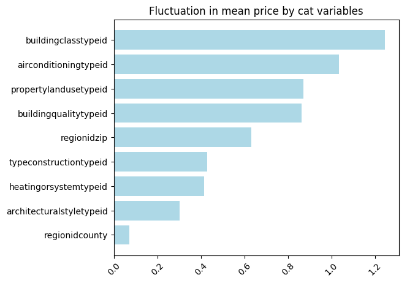

```python
# Plot the fluctuation in mean price by cat variables

plt.rcdefaults()
#fig, ax = plt.subplots()
plt.figure(figsize=(6, 5))
x, y = zip(*sorted(std_by_type.items(), key=lambda x: x[1])) # unpack a list of pairs into two tuples
plt.xticks(rotation=45)
plt.barh(x, y, align='center',
        color='lightblue', ecolor='grey')
plt.title('Fluctuation in mean price by cat variables')
plt.savefig('fluc_cat_plot.png')
plt.show()
```

```python
high_type = ['propertylandusetypeid', 'buildingqualitytypeid', 'regionidcounty'] #'airconditioningtypeid'
```

### Now we combine the them into our final features to use

```python
feat = high_num + high_type
feat
```

```
['calculatedfinishedsquarefeet',
 'calculatedbathnbr',
 'bedroomcnt',
 'propertylandusetypeid',
 'buildingqualitytypeid',
 'regionidcounty']
```

```python
HouseDf[feat+['taxvaluedollarcnt']].show(6)
```

```
+----------------------------+-----------------+----------+---------------------+---------------------+--------------+-----------------+
|calculatedfinishedsquarefeet|calculatedbathnbr|bedroomcnt|propertylandusetypeid|buildingqualitytypeid|regionidcounty|taxvaluedollarcnt|
+----------------------------+-----------------+----------+---------------------+---------------------+--------------+-----------------+
|          1813.5716483779934|2.295578341765764|       0.0|                  269|                    7|          3101|              9.0|
|          1813.5716483779934|2.295578341765764|       0.0|                  261|                    7|          3101|          27516.0|
|                     73026.0|2.295578341765764|       0.0|                   47|                    7|          3101|        1413387.0|
|                      5068.0|2.295578341765764|       0.0|                   47|                    7|          3101|        1156834.0|
|                      1776.0|2.295578341765764|       0.0|                   31|                    7|          3101|         433491.0|
|                      2400.0|2.295578341765764|       0.0|                   31|                    7|          3101|         283315.0|
+----------------------------+-----------------+----------+---------------------+---------------------+--------------+-----------------+
only showing top 6 rows
```

```python
HouseDf[feat+['taxvaluedollarcnt']].select('taxvaluedollarcnt').describe().toPandas().transpose()
```

|  | 0 | 1 | 2 | 3 | 4 |
| --- | --- | --- | --- | --- | --- |
| summary | count | mean | stddev | min | max |
| taxvaluedollarcnt | 2683820 | 408774.56437025446 | 597044.5781729617 | 1.0 | 1.49613482E8 |

```python
from pyspark.sql.functions import udf, col, avg, mean, stddev
import pyspark.sql.functions as f
```

#### Remove outliers in 'taxvaluedollarcnt' using 3 std as upper limit

```python
filter_HouseDf = HouseDf[feat+['taxvaluedollarcnt']].filter((f.col('taxvaluedollarcnt') < 411496 + 3*600599) & (f.col('taxvaluedollarcnt') > 10000))

print (" Number of rows remaining after removal:", '\t', filter_HouseDf.count(),
       "\n Number of outlier rows removed from DataFrame:", '\t', HouseDf.count() - filter_HouseDf.count(),
       "\n The upper limit above which is considered to be outliers:", 411496 + 3*600599)
```

```
 Number of rows remaining after removal: 	 2644905
 Number of outlier rows removed from DataFrame: 	 38915
 The upper limit above which is considered to be outliers: 2213293
```

### Histogram of the cleaned 'taxvaluedollarcnt'

```
array([[<matplotlib.axes._subplots.AxesSubplot object at 0x7f63c05dfe10>]],
      dtype=object)
```

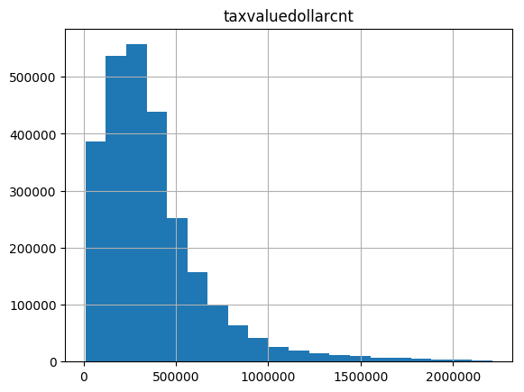

```python
filter_HouseDf.select('taxvaluedollarcnt').toPandas().hist(bins=20)
```

#### Review of dropped variables

```python
for col in house2016.columns:
    if col not in feat:
        print('removed column: ', col)
```

```
removed column:  parcelid
removed column:  airconditioningtypeid
removed column:  architecturalstyletypeid
removed column:  basementsqft
removed column:  bathroomcnt
removed column:  buildingclasstypeid
removed column:  decktypeid
removed column:  finishedfloor1squarefeet
removed column:  finishedsquarefeet12
removed column:  finishedsquarefeet13
removed column:  finishedsquarefeet15
removed column:  finishedsquarefeet50
removed column:  finishedsquarefeet6
removed column:  fips
removed column:  fireplacecnt
removed column:  fullbathcnt
removed column:  garagecarcnt
removed column:  garagetotalsqft
removed column:  hashottuborspa
removed column:  heatingorsystemtypeid
removed column:  latitude
removed column:  longitude
removed column:  lotsizesquarefeet
removed column:  poolcnt
removed column:  poolsizesum
removed column:  pooltypeid10
removed column:  pooltypeid2
removed column:  pooltypeid7
removed column:  propertycountylandusecode
removed column:  propertyzoningdesc
removed column:  rawcensustractandblock
removed column:  regionidcity
removed column:  regionidneighborhood
removed column:  regionidzip
removed column:  roomcnt
removed column:  storytypeid
removed column:  threequarterbathnbr
removed column:  typeconstructiontypeid
removed column:  unitcnt
removed column:  yardbuildingsqft17
removed column:  yardbuildingsqft26
removed column:  yearbuilt
removed column:  numberofstories
removed column:  fireplaceflag
removed column:  structuretaxvaluedollarcnt
removed column:  taxvaluedollarcnt
removed column:  assessmentyear
removed column:  landtaxvaluedollarcnt
removed column:  taxamount
removed column:  taxdelinquencyflag
removed column:  taxdelinquencyyear
removed column:  censustractandblock
```

```python
feat
```

```
['calculatedfinishedsquarefeet',
 'calculatedbathnbr',
 'bedroomcnt',
 'propertylandusetypeid',
 'buildingqualitytypeid',
 'regionidcounty']
```

```python
featureCols = feat
```

```python
featureCols
```

```
['calculatedfinishedsquarefeet',
 'calculatedbathnbr',
 'bedroomcnt',
 'propertylandusetypeid',
 'buildingqualitytypeid',
 'regionidcounty']
```

```python
labelCol = 'taxvaluedollarcnt'
House_mod = filter_HouseDf[featureCols + [labelCol]].dropna(how='any')
```

```python
House_mod.printSchema()
```

```
root
 |-- calculatedfinishedsquarefeet: double (nullable = false)
 |-- calculatedbathnbr: double (nullable = false)
 |-- bedroomcnt: double (nullable = false)
 |-- propertylandusetypeid: integer (nullable = true)
 |-- buildingqualitytypeid: integer (nullable = true)
 |-- regionidcounty: string (nullable = true)
 |-- taxvaluedollarcnt: double (nullable = false)
```

### To cut the tax assessment, we first re-plot the histogram of the response variable with 25 bins

```
array([[<matplotlib.axes._subplots.AxesSubplot object at 0x7f62f2e9a080>]],
      dtype=object)
```

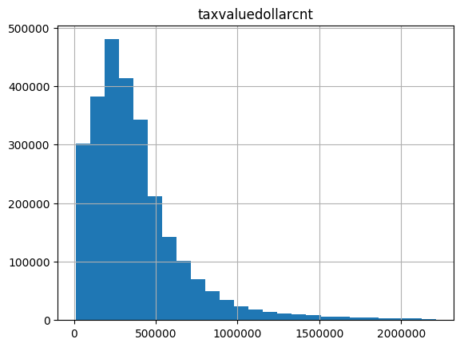

```python
House_mod.select('taxvaluedollarcnt').toPandas().hist(bins=25)
```

#### We see the number of houses jumped quite a lot around 480000 to 500000, therefore, we decide to use 485000 as the cutting point

```python
from pyspark.ml.feature import Bucketizer

# outlierUpperLim = mean_exp + 5*std_exp
# bucketSize = 3 # TODO
# upperLim = int(outlierUpperLim + bucketSize)
splits = [0, 485000, float("inf")]

bucketizer = Bucketizer(splits=splits, inputCol="taxvaluedollarcnt", outputCol="ValueBucketed")

# Transform original data into its bucket index.
bucketed_house = bucketizer.transform(House_mod)

# print("Bucketizer output with ", bucketSize, "buckets")
bucketed_house.select("ValueBucketed").show(5)
```

```
+-------------+
|ValueBucketed|
+-------------+
|          0.0|
|          1.0|
|          1.0|
|          0.0|
|          0.0|
+-------------+
only showing top 5 rows
```

#### Histogram of bucket

```
array([[<matplotlib.axes._subplots.AxesSubplot object at 0x7f632dfac668>]],
      dtype=object)
```

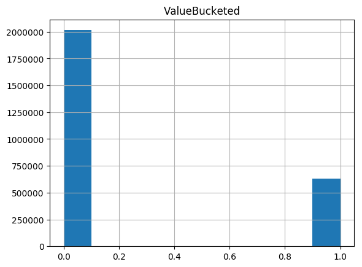

```python
bucketed_house.select("ValueBucketed").toPandas().hist()
```

```python
bucketed_house.printSchema()
```

```
root
 |-- calculatedfinishedsquarefeet: double (nullable = false)
 |-- calculatedbathnbr: double (nullable = false)
 |-- bedroomcnt: double (nullable = false)
 |-- propertylandusetypeid: integer (nullable = true)
 |-- buildingqualitytypeid: integer (nullable = true)
 |-- regionidcounty: string (nullable = true)
 |-- taxvaluedollarcnt: double (nullable = false)
 |-- ValueBucketed: double (nullable = true)
```

```python
high_type
```

```
['propertylandusetypeid', 'buildingqualitytypeid', 'regionidcounty']
```

# data_pr.show(5)

```python
from pyspark.ml.feature import StringIndexer
from pyspark.ml import Pipeline

indexers = [StringIndexer(inputCol=c, outputCol=c+"_ind").fit(bucketed_house) for c in high_type]

pipeline = Pipeline(stages=indexers)
df_bucketed_house = pipeline.fit(bucketed_house).transform(bucketed_house)
```

```python
ind_col = [col for col in df_bucketed_house.columns if "_ind" in col]
```

```python
ind_col
```

```
['propertylandusetypeid_ind',
 'buildingqualitytypeid_ind',
 'regionidcounty_ind']
```

```python
featureCols[:3]
```

```
['calculatedfinishedsquarefeet', 'calculatedbathnbr', 'bedroomcnt']
```

### Final features in the model

```python
ind_featureCols = featureCols[:3] + ind_col
ind_featureCols
```

```
['calculatedfinishedsquarefeet',
 'calculatedbathnbr',
 'bedroomcnt',
 'propertylandusetypeid_ind',
 'buildingqualitytypeid_ind',
 'regionidcounty_ind']
```

```python
new_house2016 = df_bucketed_house[ind_featureCols+['ValueBucketed']]
```

```python
new_house2016.printSchema()
```

```
root
 |-- calculatedfinishedsquarefeet: double (nullable = false)
 |-- calculatedbathnbr: double (nullable = false)
 |-- bedroomcnt: double (nullable = false)
 |-- propertylandusetypeid_ind: double (nullable = false)
 |-- buildingqualitytypeid_ind: double (nullable = false)
 |-- regionidcounty_ind: double (nullable = false)
 |-- ValueBucketed: double (nullable = true)
```

```python
from pyspark.ml.feature import VectorAssembler
from pyspark.ml.feature import VectorIndexer

assembler = VectorAssembler(inputCols=ind_featureCols, outputCol="features")
```

```python
model_house2016 = assembler.transform(new_house2016)[['features', 'ValueBucketed']]
```

### train, test split

```python
trainDf, testDf = model_house2016.randomSplit([0.75, 0.25], seed=12345)
trainDf.show(5)
testDf.show(5)
```

```
+--------------------+-------------+
|            features|ValueBucketed|
+--------------------+-------------+
|(6,[0,1],[63.0,2....|          0.0|
|(6,[0,1],[78.0,1.0])|          0.0|
|(6,[0,1],[96.0,2....|          0.0|
|(6,[0,1],[99.0,2....|          0.0|
|(6,[0,1],[110.0,2...|          0.0|
+--------------------+-------------+
only showing top 5 rows

+--------------------+-------------+
|            features|ValueBucketed|
+--------------------+-------------+
|(6,[0,1],[100.0,2...|          0.0|
|(6,[0,1],[120.0,2...|          0.0|
|(6,[0,1],[132.0,2...|          0.0|
|(6,[0,1],[171.0,2...|          0.0|
|(6,[0,1],[173.0,2...|          0.0|
+--------------------+-------------+
only showing top 5 rows
```

### Train using decision tree classifier

```python
from pyspark.ml.classification import DecisionTreeClassifier

treeModel = DecisionTreeClassifier(labelCol='ValueBucketed',
                                   featuresCol='features',
                                   maxDepth=25)

# Fit the model
modelNoTuning = treeModel.fit(trainDf)
```

### Test to see performance: the test and training accuracy is almost identical, we hence believe the model is robust to complete our classification task

```python
from pyspark.ml.classification import DecisionTreeClassifier
from pyspark.ml.evaluation import MulticlassClassificationEvaluator

predDf_ts = modelNoTuning.transform(testDf)
predDf_tr = modelNoTuning.transform(trainDf)

evaluator = MulticlassClassificationEvaluator(
    labelCol="ValueBucketed", predictionCol="prediction", metricName="accuracy")

accuracy_ts = evaluator.evaluate(predDf_ts)
accuracy_tr = evaluator.evaluate(predDf_tr)
print("Test Acc = %g " % (accuracy_ts))
print("Train Acc = %g " % (accuracy_tr))
```

```
Test Acc = 0.823976
Train Acc = 0.825503
```

### Confusion Matrix Evaluation

```python
from sklearn.metrics import confusion_matrix
from plot_helper import plot_confusion_matrix

labelCol = 'ValueBucketed'
classes = predDf_ts.select(labelCol).groupBy(labelCol)\
                        .count().sort('count', ascending=False).toPandas()
classLabels = classes[labelCol].values.tolist()


yTrue = predDf_ts.select('ValueBucketed').toPandas()
yPred = predDf_ts.select('prediction').toPandas()
cnfMatrix = confusion_matrix(yTrue, yPred)
cnfMatrix
```

```
array([[477902,  24972],
       [ 91312,  66427]])
```

```
Confusion matrix, without normalization
[[477902  24972]
 [ 91312  66427]]
```

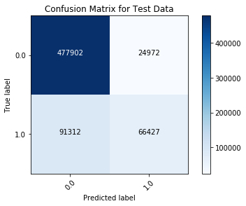

```python
import matplotlib.pyplot as plt

%matplotlib inline

plt.figure()
plot_confusion_matrix(cnfMatrix, title="Confusion Matrix for Test Data", classes=classLabels)
plt.show()
```

```python
classLabels = [str(cl) for cl in classLabels]
classLabels
```

```
['0.0', '1.0']
```

### Report the mdoel performance

```python
from sklearn.metrics import classification_report

# print (classification_report(yTrue, yPred, target_names=labelClasses))
print (classification_report(yTrue, yPred, target_names=classLabels))
```

```
              precision    recall  f1-score   support

         0.0       0.84      0.95      0.89    502874
         1.0       0.73      0.42      0.53    157739

   micro avg       0.82      0.82      0.82    660613
   macro avg       0.78      0.69      0.71    660613
weighted avg       0.81      0.82      0.81    660613
```